# Covid Analysis

Monika Zielińska

01.12.2020

## Executive summary

The dataset contains blood results of patients admitted to the hospital Tongji (Wuhan, China) between 10 January and 18 February 2020. The data collection method and basic statistics were used in the [article Tan et al](https://www.nature.com/articles/s42256-020-0180-7).

Each row in the dataset contains information about patient and the specific blood test results. Because tests don’t check every biomarker, there are many NA values. For further analysis NA values were filled with the closest earlier value and if it is not possible - closest latest value for a patient. If the patient doesn’t have any results for the biomarker then the value is kept as NA.

Analysis of the basic patient information showed that age is one of the most important factors in survivability of the illness.

During biomarkers analysis 3 biomarkers were chosen that showed the most potential for using it to predict surival chances of the patients - lymphocytes(%), D-D dimer and high-sensitivity C-reactive protein (hs-CRP).

## Patients data overview

The dataset contains 6120 blood tests of 375 patients.

The patients were categorized by age into young adults (18-30 years), adults (31-65 years) and elderly (> 65 years) for easier way to show dependencies.

|  | patient_id | gender | age | age_group | admission_time | discharge_time | survived | length_of_stay |
| --- | --- | --- | --- | --- | --- | --- | --- | --- |
|  | Min. : 1.0 | female:151 | Min. :18.00 | young adult: 22 | Min. :2020-01-10 15:52:20 | Min. :2020-01-23 09:09:23 | no :174 | Min. : 0.0847 |
|  | 1st Qu.: 94.5 | male :224 | 1st Qu.:46.00 | adult :192 | 1st Qu.:2020-02-01 19:27:40 | 1st Qu.:2020-02-11 13:39:21 | yes:201 | 1st Qu.: 4.4845 |
|  | Median :188.0 | NA | Median :62.00 | elderly :161 | Median :2020-02-04 22:30:34 | Median :2020-02-16 17:40:07 | NA | Median : 9.5942 |
|  | Mean :188.0 | NA | Mean :58.83 | NA | Mean :2020-02-04 20:13:51 | Mean :2020-02-15 16:42:59 | NA | Mean :10.8536 |
|  | 3rd Qu.:281.5 | NA | 3rd Qu.:70.00 | NA | 3rd Qu.:2020-02-10 04:11:10 | 3rd Qu.:2020-02-19 11:47:14 | NA | 3rd Qu.:15.6876 |
|  | Max. :375.0 | NA | Max. :95.00 | NA | Max. :2020-02-17 21:30:07 | Max. :2020-03-04 16:21:51 | NA | Max. :35.1708 |

Looking at the summary, most of the patients are middle or older aged. The dataset contains also more males than females and more people survived than not.

### Survival vs age and gender

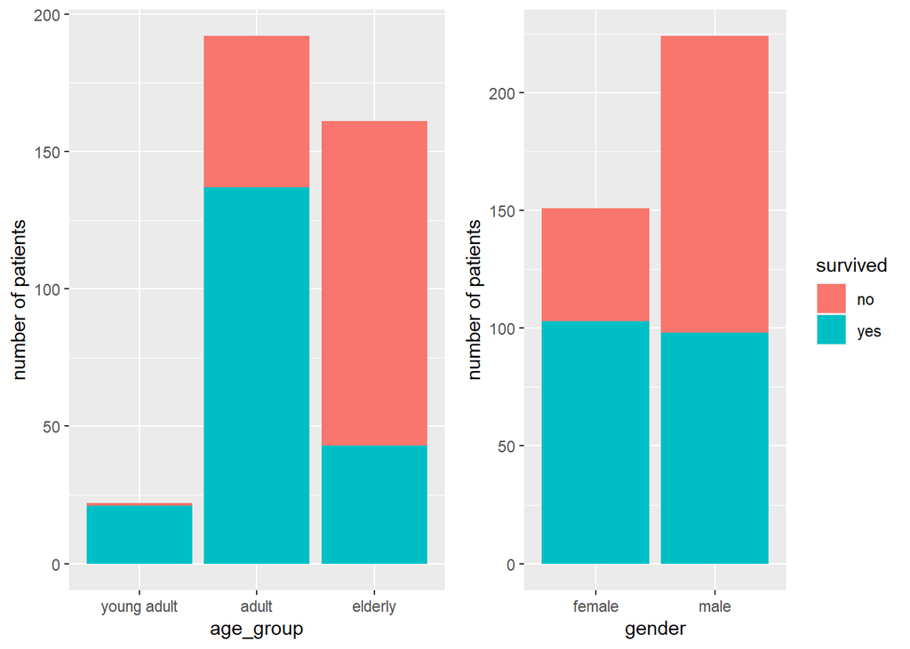

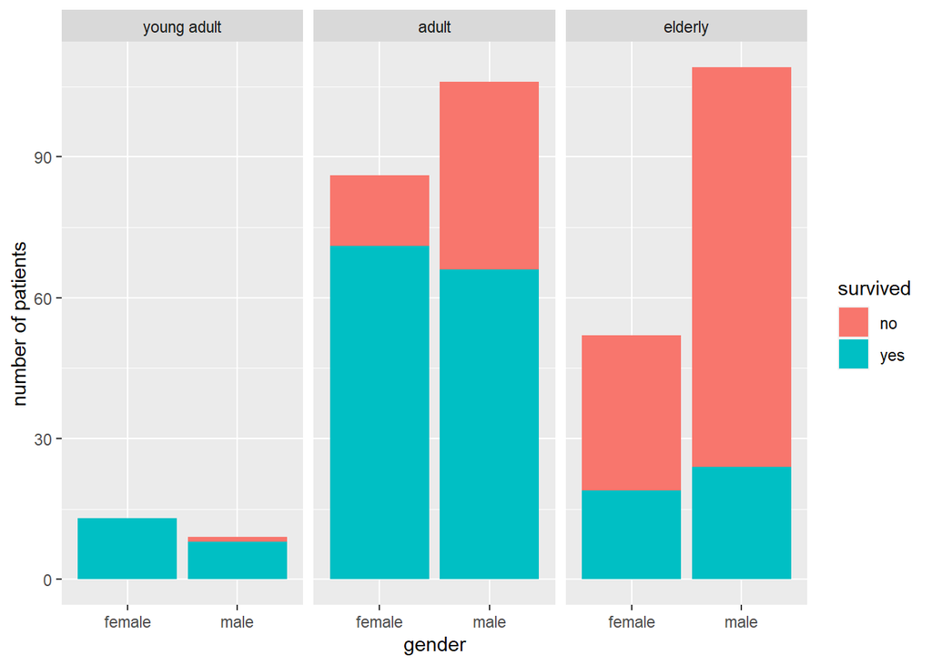

At first it looks like males are more likely to die, but the survival rates depends mostly on age of the patient. Survival rates for elderly are much worse and most of the patients in this age group are males.

### Survival vs length of the stay

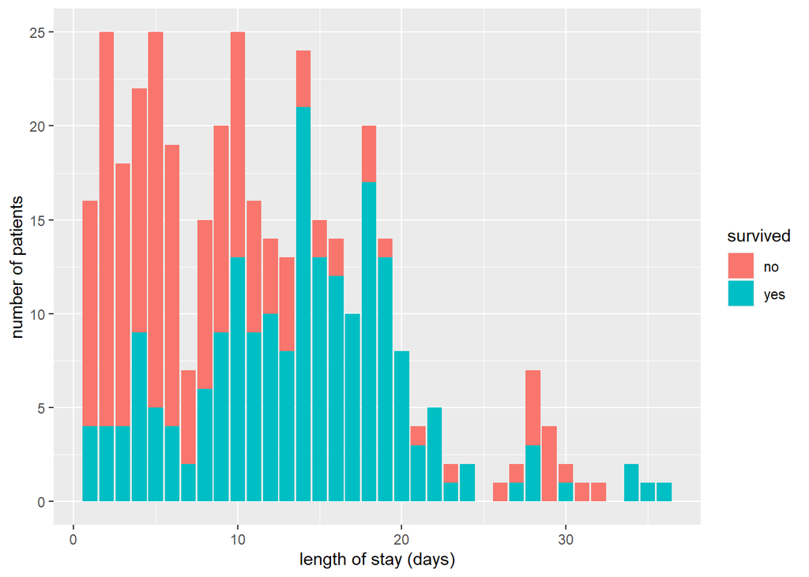

There is a high mortality rate for the first few days of the stay in hospital. Most likely, because people without symptoms wouldn’t be in a hospital and people with symptoms are unlikely to get discharged after only with days. As the length of the stay gets longer, survival rates get better.

### Cummulative sum of deaths and survivals over time

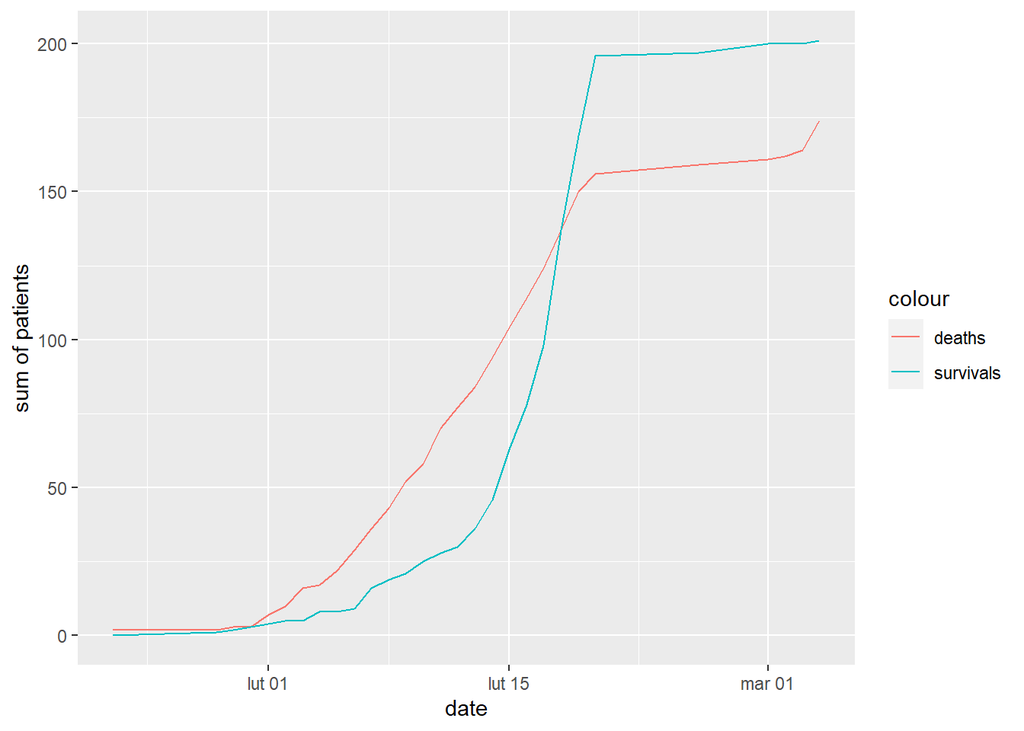

## Atributes

### Summary

Below are summaries of all available attributes before and after cleaning the dataset.

**Show/Hide all attributes before data cleaning**

| PATIENT_ID | Min. : 1.0 | 1st Qu.: 94.5 | Median :188.0 | Mean :188.0 | 3rd Qu.:281.5 | Max. :375.0 | NA’s :5745 |
| --- | --- | --- | --- | --- | --- | --- | --- |
| RE_DATE | Min. :2020-01-10 19:45:00 | 1st Qu.:2020-02-04 13:44:00 | Median :2020-02-09 12:42:30 | Mean :2020-02-08 07:00:02 | 3rd Qu.:2020-02-13 10:34:00 | Max. :2020-02-18 17:49:00 | NA’s :14 |
| age | Min. :18.00 | 1st Qu.:47.00 | Median :62.00 | Mean :59.44 | 3rd Qu.:71.00 | Max. :95.00 | NA |
| gender | Min. :1.000 | 1st Qu.:1.000 | Median :1.000 | Mean :1.391 | 3rd Qu.:2.000 | Max. :2.000 | NA |
| Admission.time | Min. :2020-01-10 15:52:20 | 1st Qu.:2020-02-01 00:06:16 | Median :2020-02-04 15:53:12 | Mean :2020-02-03 18:57:56 | 3rd Qu.:2020-02-09 02:06:58 | Max. :2020-02-17 21:30:07 | NA |
| Discharge.time | Min. :2020-01-23 09:09:23 | 1st Qu.:2020-02-13 19:06:26 | Median :2020-02-17 21:50:30 | Mean :2020-02-16 21:40:09 | 3rd Qu.:2020-02-19 13:30:26 | Max. :2020-03-04 16:21:51 | NA |
| outcome | Min. :0.0000 | 1st Qu.:0.0000 | Median :0.0000 | Mean :0.4747 | 3rd Qu.:1.0000 | Max. :1.0000 | NA |
| Hypersensitive.cardiac.troponinI | Min. : 1.9 | 1st Qu.: 4.4 | Median : 20.6 | Mean : 1223.2 | 3rd Qu.: 223.8 | Max. :50000.0 | NA’s :5613 |
| hemoglobin | Min. : 6.4 | 1st Qu.:113.0 | Median :125.0 | Mean :123.1 | 3rd Qu.:137.0 | Max. :178.0 | NA’s :5145 |
| Serum.chloride | Min. : 71.50 | 1st Qu.: 99.05 | Median :102.10 | Mean :103.14 | 3rd Qu.:105.65 | Max. :140.40 | NA’s :5145 |
| Prothrombin.time | Min. : 11.50 | 1st Qu.: 13.60 | Median : 14.80 | Mean : 16.68 | 3rd Qu.: 16.70 | Max. :120.00 | NA’s :5458 |
| procalcitonin | Min. : 0.020 | 1st Qu.: 0.040 | Median : 0.100 | Mean : 1.107 | 3rd Qu.: 0.405 | Max. :57.170 | NA’s :5661 |
| eosinophils… | Min. :0.000 | 1st Qu.:0.000 | Median :0.100 | Mean :0.629 | 3rd Qu.:0.800 | Max. :8.600 | NA’s :5163 |
| Interleukin.2.receptor | Min. : 61.0 | 1st Qu.: 459.5 | Median : 676.5 | Mean : 907.2 | 3rd Qu.:1155.5 | Max. :7500.0 | NA’s :5852 |
| Alkaline.phosphatase | Min. : 17.00 | 1st Qu.: 54.00 | Median : 69.50 | Mean : 82.47 | 3rd Qu.: 95.00 | Max. :620.00 | NA’s :5190 |
| albumin | Min. :13.60 | 1st Qu.:27.40 | Median :32.20 | Mean :32.01 | 3rd Qu.:36.60 | Max. :48.60 | NA’s :5186 |
| basophil… | Min. :0.00 | 1st Qu.:0.10 | Median :0.20 | Mean :0.21 | 3rd Qu.:0.30 | Max. :1.70 | NA’s :5163 |
| Interleukin.10 | Min. : 5.00 | 1st Qu.: 5.00 | Median : 5.90 | Mean : 16.07 | 3rd Qu.: 12.35 | Max. :1000.00 | NA’s :5853 |
| Total.bilirubin | Min. : 2.50 | 1st Qu.: 7.40 | Median : 10.70 | Mean : 16.70 | 3rd Qu.: 16.77 | Max. :505.70 | NA’s :5190 |
| Platelet.count | Min. : -1.0 | 1st Qu.:109.0 | Median :178.0 | Mean :184.3 | 3rd Qu.:248.0 | Max. :558.0 | NA’s :5163 |
| monocytes… | Min. : 0.300 | 1st Qu.: 2.800 | Median : 5.700 | Mean : 6.155 | 3rd Qu.: 8.600 | Max. :53.000 | NA’s :5162 |
| antithrombin | Min. : 20.00 | 1st Qu.: 74.00 | Median : 86.00 | Mean : 85.32 | 3rd Qu.: 97.00 | Max. :136.00 | NA’s :5790 |
| Interleukin.8 | Min. : 5.000 | 1st Qu.: 8.675 | Median : 16.000 | Mean : 83.088 | 3rd Qu.: 35.200 | Max. :6795.000 | NA’s :5852 |
| indirect.bilirubin | Min. : 0.100 | 1st Qu.: 3.800 | Median : 5.400 | Mean : 6.889 | 3rd Qu.: 8.000 | Max. :145.100 | NA’s :5214 |
| Red.blood.cell.distribution.width | Min. :10.60 | 1st Qu.:12.00 | Median :12.60 | Mean :13.07 | 3rd Qu.:13.70 | Max. :27.10 | NA’s :5197 |
| neutrophils… | Min. : 1.7 | 1st Qu.:65.1 | Median :82.4 | Mean :77.6 | 3rd Qu.:92.3 | Max. :98.9 | NA’s :5163 |
| total.protein | Min. :31.80 | 1st Qu.:61.00 | Median :65.90 | Mean :65.30 | 3rd Qu.:70.45 | Max. :88.70 | NA’s :5189 |
| Quantification.of.Treponema.pallidum.antibodies | Min. : 0.020 | 1st Qu.: 0.040 | Median : 0.050 | Mean : 0.132 | 3rd Qu.: 0.070 | Max. :11.950 | NA’s :5841 |
| Prothrombin.activity | Min. : 6.00 | 1st Qu.: 65.00 | Median : 81.00 | Mean : 78.55 | 3rd Qu.: 95.00 | Max. :142.00 | NA’s :5461 |
| HBsAg | Min. : 0.000 | 1st Qu.: 0.000 | Median : 0.010 | Mean : 8.306 | 3rd Qu.: 0.010 | Max. :250.000 | NA’s :5841 |
| mean.corpuscular.volume | Min. : 61.60 | 1st Qu.: 86.90 | Median : 90.10 | Mean : 90.39 | 3rd Qu.: 93.90 | Max. :118.90 | NA’s :5163 |
| hematocrit | Min. :14.50 | 1st Qu.:33.50 | Median :36.60 | Mean :36.55 | 3rd Qu.:39.90 | Max. :52.30 | NA’s :5163 |
| White.blood.cell.count | Min. : 0.13 | 1st Qu.: 4.94 | Median : 7.72 | Mean : 15.60 | 3rd Qu.: 12.72 | Max. :1726.60 | NA’s :4993 |
| Tumor.necrosis.factor.U.03B1. | Min. : 4.00 | 1st Qu.: 6.70 | Median : 8.60 | Mean : 11.58 | 3rd Qu.: 11.50 | Max. :168.00 | NA’s :5852 |
| mean.corpuscular.hemoglobin.concentration | Min. :286.0 | 1st Qu.:333.0 | Median :343.0 | Mean :342.8 | 3rd Qu.:350.0 | Max. :514.0 | NA’s :5163 |
| fibrinogen | Min. : 0.500 | 1st Qu.: 3.050 | Median : 4.120 | Mean : 4.294 | 3rd Qu.: 5.480 | Max. :10.780 | NA’s :5554 |
| Interleukin.1ß | Min. : 5.00 | 1st Qu.: 5.00 | Median : 5.00 | Mean : 6.51 | 3rd Qu.: 5.00 | Max. :88.50 | NA’s :5852 |
| Urea | Min. : 0.800 | 1st Qu.: 4.000 | Median : 5.985 | Mean : 9.589 | 3rd Qu.:11.400 | Max. :68.400 | NA’s :5184 |
| lymphocyte.count | Min. : 0.000 | 1st Qu.: 0.460 | Median : 0.800 | Mean : 1.017 | 3rd Qu.: 1.310 | Max. :52.420 | NA’s :5163 |
| PH.value | Min. :5.000 | 1st Qu.:6.000 | Median :6.500 | Mean :6.484 | 3rd Qu.:7.294 | Max. :7.565 | NA’s :5736 |
| Red.blood.cell.count | Min. : 0.100 | 1st Qu.: 3.680 | Median : 4.140 | Mean : 9.288 | 3rd Qu.: 4.650 | Max. :749.500 | NA’s :4993 |
| Eosinophil.count | Min. :0.000 | 1st Qu.:0.000 | Median :0.010 | Mean :0.039 | 3rd Qu.:0.060 | Max. :0.490 | NA’s :5163 |
| Corrected.calcium | Min. :1.650 | 1st Qu.:2.270 | Median :2.360 | Mean :2.355 | 3rd Qu.:2.440 | Max. :2.790 | NA’s :5206 |
| Serum.potassium | Min. : 2.760 | 1st Qu.: 3.950 | Median : 4.410 | Mean : 4.509 | 3rd Qu.: 4.870 | Max. :12.800 | NA’s :5140 |
| glucose | Min. : 1.000 | 1st Qu.: 5.550 | Median : 6.990 | Mean : 8.889 | 3rd Qu.:10.260 | Max. :43.010 | NA’s :5345 |
| neutrophils.count | Min. : 0.06 | 1st Qu.: 3.09 | Median : 5.85 | Mean : 7.81 | 3rd Qu.:10.95 | Max. :33.88 | NA’s :5163 |
| Direct.bilirubin | Min. : 1.600 | 1st Qu.: 3.225 | Median : 4.800 | Mean : 9.887 | 3rd Qu.: 8.275 | Max. :360.600 | NA’s :5190 |
| Mean.platelet.volume | Min. : 8.50 | 1st Qu.:10.10 | Median :10.80 | Mean :10.91 | 3rd Qu.:11.50 | Max. :15.00 | NA’s :5258 |
| ferritin | Min. : 17.8 | 1st Qu.: 377.2 | Median : 711.0 | Mean : 1379.1 | 3rd Qu.: 1425.2 | Max. :50000.0 | NA’s :5837 |
| RBC.distribution.width.SD | Min. : 31.30 | 1st Qu.: 38.50 | Median : 40.90 | Mean : 42.44 | 3rd Qu.: 44.70 | Max. :113.30 | NA’s :5197 |
| Thrombin.time | Min. : 13.00 | 1st Qu.: 15.60 | Median : 16.80 | Mean : 18.17 | 3rd Qu.: 18.38 | Max. :161.90 | NA’s :5554 |
| …lymphocyte | Min. : 0.000 | 1st Qu.: 3.925 | Median :11.450 | Mean :15.392 | 3rd Qu.:24.975 | Max. :60.000 | NA’s :5162 |
| HCV.antibody.quantification | Min. :0.020 | 1st Qu.:0.040 | Median :0.060 | Mean :0.117 | 3rd Qu.:0.090 | Max. :2.090 | NA’s :5841 |
| D.D.dimer | Min. : 0.210 | 1st Qu.: 0.603 | Median : 2.155 | Mean : 7.943 | 3rd Qu.:21.000 | Max. :60.000 | NA’s :5490 |
| Total.cholesterol | Min. :0.100 | 1st Qu.:3.010 | Median :3.630 | Mean :3.689 | 3rd Qu.:4.265 | Max. :7.300 | NA’s :5189 |
| aspartate.aminotransferase | Min. : 6.00 | 1st Qu.: 19.50 | Median : 27.00 | Mean : 46.53 | 3rd Qu.: 42.00 | Max. :1858.00 | NA’s :5185 |
| Uric.acid | Min. : 43.0 | 1st Qu.: 183.2 | Median : 243.7 | Mean : 276.1 | 3rd Qu.: 333.8 | Max. :1176.0 | NA’s :5186 |
| HCO3. | Min. : 6.30 | 1st Qu.:21.00 | Median :23.50 | Mean :23.14 | 3rd Qu.:25.90 | Max. :36.30 | NA’s :5186 |
| calcium | Min. :1.170 | 1st Qu.:1.980 | Median :2.080 | Mean :2.078 | 3rd Qu.:2.190 | Max. :2.620 | NA’s :5141 |
| Amino.terminal.brain.natriuretic.peptide.precursor.NT.proBNP. | Min. : 5 | 1st Qu.: 150 | Median : 585 | Mean : 3669 | 3rd Qu.: 2625 | Max. :70000 | NA’s :5645 |
| Lactate.dehydrogenase | Min. : 110.0 | 1st Qu.: 218.0 | Median : 340.0 | Mean : 474.2 | 3rd Qu.: 601.8 | Max. :1867.0 | NA’s :5186 |
| platelet.large.cell.ratio | Min. :11.20 | 1st Qu.:25.60 | Median :30.90 | Mean :31.77 | 3rd Qu.:37.20 | Max. :62.20 | NA’s :5258 |
| Interleukin.6 | Min. : 1.500 | 1st Qu.: 4.772 | Median : 19.265 | Mean : 112.308 | 3rd Qu.: 60.167 | Max. :5000.000 | NA’s :5848 |
| Fibrin.degradation.products | Min. : 4.00 | 1st Qu.: 4.00 | Median : 17.90 | Mean : 61.35 | 3rd Qu.:150.00 | Max. :190.80 | NA’s :5790 |
| monocytes.count | Min. : 0.010 | 1st Qu.: 0.270 | Median : 0.410 | Mean : 0.526 | 3rd Qu.: 0.580 | Max. :39.920 | NA’s :5163 |
| PLT.distribution.width | Min. : 8.00 | 1st Qu.:11.10 | Median :12.40 | Mean :13.01 | 3rd Qu.:14.30 | Max. :25.30 | NA’s :5258 |
| globulin | Min. :10.10 | 1st Qu.:29.70 | Median :32.70 | Mean :33.24 | 3rd Qu.:36.50 | Max. :50.60 | NA’s :5190 |
| .U.03B3..glutamyl.transpeptidase | Min. : 3.00 | 1st Qu.: 22.00 | Median : 34.00 | Mean : 55.34 | 3rd Qu.: 58.00 | Max. :732.00 | NA’s :5190 |
| International.standard.ratio | Min. : 0.840 | 1st Qu.: 1.030 | Median : 1.140 | Mean : 1.313 | 3rd Qu.: 1.330 | Max. :13.480 | NA’s :5461 |
| basophil.count… | Min. :0.000 | 1st Qu.:0.010 | Median :0.010 | Mean :0.017 | 3rd Qu.:0.020 | Max. :0.120 | NA’s :5163 |
| ..2019.nCoV.nucleic.acid.detection | Min. :-1 | 1st Qu.:-1 | Median :-1 | Mean :-1 | 3rd Qu.:-1 | Max. :-1 | NA’s :5619 |
| mean.corpuscular.hemoglobin | Min. :20.4 | 1st Qu.:29.7 | Median :30.9 | Mean :31.0 | 3rd Qu.:32.2 | Max. :50.8 | NA’s :5163 |
| Activation.of.partial.thromboplastin.time | Min. : 21.80 | 1st Qu.: 35.30 | Median : 39.20 | Mean : 41.52 | 3rd Qu.: 44.12 | Max. :144.00 | NA’s :5552 |
| High.sensitivity.C.reactive.protein | Min. : 0.10 | 1st Qu.: 5.70 | Median : 51.50 | Mean : 76.24 | 3rd Qu.:118.50 | Max. :320.00 | NA’s :5383 |
| HIV.antibody.quantification | Min. :0.05 | 1st Qu.:0.07 | Median :0.09 | Mean :0.10 | 3rd Qu.:0.11 | Max. :0.27 | NA’s :5842 |
| serum.sodium | Min. :115.4 | 1st Qu.:137.7 | Median :140.4 | Mean :141.6 | 3rd Qu.:143.5 | Max. :179.7 | NA’s :5145 |
| thrombocytocrit | Min. :0.010 | 1st Qu.:0.150 | Median :0.210 | Mean :0.212 | 3rd Qu.:0.270 | Max. :0.510 | NA’s :5258 |
| ESR | Min. : 1.00 | 1st Qu.: 14.00 | Median : 28.00 | Mean : 33.69 | 3rd Qu.: 45.50 | Max. :110.00 | NA’s :5737 |
| glutamic.pyruvic.transaminase | Min. : 5.00 | 1st Qu.: 16.00 | Median : 24.00 | Mean : 38.86 | 3rd Qu.: 41.00 | Max. :1600.00 | NA’s :5189 |
| eGFR | Min. : 2.00 | 1st Qu.: 63.58 | Median : 87.90 | Mean : 81.56 | 3rd Qu.:103.97 | Max. :224.00 | NA’s :5184 |
| creatinine | Min. : 11.00 | 1st Qu.: 58.00 | Median : 76.00 | Mean : 109.93 | 3rd Qu.: 98.25 | Max. :1497.00 | NA’s :5184 |

**Show/Hide all attributes after data cleaning**

| patient_id | Min. : 1.0 | 1st Qu.: 92.0 | Median :185.0 | Mean :184.8 | 3rd Qu.:270.0 | Max. :375.0 | NA |
| --- | --- | --- | --- | --- | --- | --- | --- |
| re_date | Min. :2020-01-10 19:45:00 | 1st Qu.:2020-02-04 13:44:00 | Median :2020-02-09 12:42:30 | Mean :2020-02-08 07:00:02 | 3rd Qu.:2020-02-13 10:34:00 | Max. :2020-02-18 17:49:00 | NA’s :14 |
| age | Min. :18.00 | 1st Qu.:47.00 | Median :62.00 | Mean :59.44 | 3rd Qu.:71.00 | Max. :95.00 | NA |
| gender | female:2390 | male :3730 | NA | NA | NA | NA | NA |
| survived | no :2905 | yes:3215 | NA | NA | NA | NA | NA |
| hypersensitive_cardiac_troponini | Min. : 1.9 | 1st Qu.: 2.7 | Median : 12.9 | Mean : 958.5 | 3rd Qu.: 59.4 | Max. :50000.0 | NA’s :1022 |
| hemoglobin | Min. : 6.4 | 1st Qu.:114.0 | Median :126.0 | Mean :125.1 | 3rd Qu.:138.0 | Max. :178.0 | NA’s :34 |
| serum_chloride | Min. : 71.5 | 1st Qu.: 98.8 | Median :101.7 | Mean :102.3 | 3rd Qu.:104.6 | Max. :140.4 | NA’s :46 |
| prothrombin_time | Min. : 11.50 | 1st Qu.: 13.50 | Median : 14.30 | Mean : 15.52 | 3rd Qu.: 15.90 | Max. :120.00 | NA’s :79 |
| procalcitonin | Min. : 0.0200 | 1st Qu.: 0.0400 | Median : 0.1000 | Mean : 0.7299 | 3rd Qu.: 0.3500 | Max. :57.1700 | NA’s :474 |
| eosinophils | Min. :0.0000 | 1st Qu.:0.0000 | Median :0.1000 | Mean :0.5679 | 3rd Qu.:0.7000 | Max. :8.6000 | NA’s :34 |
| interleukin_2_receptor | Min. : 61.0 | 1st Qu.: 513.0 | Median : 778.0 | Mean : 968.3 | 3rd Qu.:1190.0 | Max. :7500.0 | NA’s :1871 |
| alkaline_phosphatase | Min. : 17.00 | 1st Qu.: 54.00 | Median : 68.00 | Mean : 80.78 | 3rd Qu.: 91.00 | Max. :620.00 | NA’s :32 |
| albumin | Min. :13.60 | 1st Qu.:28.40 | Median :33.05 | Mean :32.72 | 3rd Qu.:37.40 | Max. :48.60 | NA’s :32 |
| basophil | Min. :0.0000 | 1st Qu.:0.1000 | Median :0.2000 | Mean :0.2012 | 3rd Qu.:0.3000 | Max. :1.7000 | NA’s :34 |
| interleukin_10 | Min. : 5.00 | 1st Qu.: 5.00 | Median : 7.50 | Mean : 18.49 | 3rd Qu.: 14.00 | Max. :1000.00 | NA’s :1884 |
| total_bilirubin | Min. : 2.50 | 1st Qu.: 7.20 | Median : 10.30 | Mean : 15.77 | 3rd Qu.: 15.40 | Max. :505.70 | NA’s :32 |
| platelet_count | Min. : -1.0 | 1st Qu.:121.0 | Median :180.0 | Mean :187.6 | 3rd Qu.:245.0 | Max. :558.0 | NA’s :34 |
| monocytes | Min. : 0.300 | 1st Qu.: 3.100 | Median : 6.000 | Mean : 6.359 | 3rd Qu.: 8.800 | Max. :53.000 | NA’s :34 |
| antithrombin | Min. : 20.00 | 1st Qu.: 77.00 | Median : 88.00 | Mean : 88.17 | 3rd Qu.: 98.00 | Max. :136.00 | NA’s :2280 |
| interleukin_8 | Min. : 5.00 | 1st Qu.: 9.90 | Median : 17.10 | Mean : 52.59 | 3rd Qu.: 38.60 | Max. :6795.00 | NA’s :1871 |
| indirect_bilirubin | Min. : 0.100 | 1st Qu.: 3.600 | Median : 5.300 | Mean : 6.801 | 3rd Qu.: 7.700 | Max. :145.100 | NA’s :49 |
| red_blood_cell_distribution_width | Min. :10.6 | 1st Qu.:11.9 | Median :12.5 | Mean :13.0 | 3rd Qu.:13.5 | Max. :27.1 | NA’s :114 |
| neutrophils | Min. : 1.7 | 1st Qu.:65.1 | Median :80.9 | Mean :77.1 | 3rd Qu.:91.6 | Max. :98.9 | NA’s :34 |
| total_protein | Min. :31.80 | 1st Qu.:62.20 | Median :66.70 | Mean :66.23 | 3rd Qu.:70.90 | Max. :88.70 | NA’s :32 |
| quantification_of_treponema_pallidum_antibodies | Min. : 0.0200 | 1st Qu.: 0.0400 | Median : 0.0500 | Mean : 0.1671 | 3rd Qu.: 0.0700 | Max. :11.9500 | NA’s :1141 |
| prothrombin_activity | Min. : 6.00 | 1st Qu.: 70.00 | Median : 86.00 | Mean : 82.58 | 3rd Qu.: 96.00 | Max. :142.00 | NA’s :79 |
| hbsag | Min. : 0.000 | 1st Qu.: 0.000 | Median : 0.010 | Mean : 6.021 | 3rd Qu.: 0.010 | Max. :250.000 | NA’s :1131 |
| mean_corpuscular_volume | Min. : 61.60 | 1st Qu.: 86.80 | Median : 89.80 | Mean : 90.04 | 3rd Qu.: 93.40 | Max. :118.90 | NA’s :34 |
| hematocrit | Min. :14.50 | 1st Qu.:33.80 | Median :36.90 | Mean :36.78 | 3rd Qu.:40.10 | Max. :52.30 | NA’s :34 |
| white_blood_cell_count | Min. : 0.13 | 1st Qu.: 4.83 | Median : 7.33 | Mean : 12.42 | 3rd Qu.: 12.18 | Max. :1726.60 | NA’s :30 |
| tumor_necrosis_factor_u_03b1 | Min. : 4.00 | 1st Qu.: 7.00 | Median : 8.70 | Mean : 11.59 | 3rd Qu.: 12.10 | Max. :168.00 | NA’s :1871 |
| mean_corpuscular_hemoglobin_concentration | Min. :286.0 | 1st Qu.:334.0 | Median :343.0 | Mean :343.4 | 3rd Qu.:351.0 | Max. :514.0 | NA’s :34 |
| fibrinogen | Min. : 0.500 | 1st Qu.: 3.260 | Median : 4.410 | Mean : 4.486 | 3rd Qu.: 5.620 | Max. :10.780 | NA’s :766 |
| interleukin_1ß | Min. : 5.000 | 1st Qu.: 5.000 | Median : 5.000 | Mean : 6.364 | 3rd Qu.: 5.000 | Max. :88.500 | NA’s :1871 |
| urea | Min. : 0.800 | 1st Qu.: 3.820 | Median : 5.600 | Mean : 8.374 | 3rd Qu.: 9.700 | Max. :68.400 | NA’s :32 |
| lymphocyte_count | Min. : 0.0000 | 1st Qu.: 0.4900 | Median : 0.7900 | Mean : 0.9754 | 3rd Qu.: 1.2800 | Max. :52.4200 | NA’s :34 |
| ph_value | Min. :5.000 | 1st Qu.:6.000 | Median :6.500 | Mean :6.410 | 3rd Qu.:7.000 | Max. :7.565 | NA’s :1671 |
| red_blood_cell_count | Min. : 0.100 | 1st Qu.: 3.700 | Median : 4.160 | Mean : 7.774 | 3rd Qu.: 4.610 | Max. :749.500 | NA’s :30 |
| eosinophil_count | Min. :0.0000 | 1st Qu.:0.0000 | Median :0.0100 | Mean :0.0342 | 3rd Qu.:0.0500 | Max. :0.4900 | NA’s :34 |
| corrected_calcium | Min. :1.650 | 1st Qu.:2.270 | Median :2.360 | Mean :2.351 | 3rd Qu.:2.430 | Max. :2.790 | NA’s :57 |
| serum_potassium | Min. : 2.760 | 1st Qu.: 3.920 | Median : 4.330 | Mean : 4.408 | 3rd Qu.: 4.780 | Max. :12.800 | NA’s :46 |
| glucose | Min. : 1.000 | 1st Qu.: 5.630 | Median : 6.960 | Mean : 8.665 | 3rd Qu.: 9.870 | Max. :43.010 | NA’s :81 |
| neutrophils_count | Min. : 0.06 | 1st Qu.: 2.97 | Median : 5.42 | Mean : 7.44 | 3rd Qu.:10.46 | Max. :33.88 | NA’s :34 |
| direct_bilirubin | Min. : 1.600 | 1st Qu.: 3.200 | Median : 4.600 | Mean : 9.006 | 3rd Qu.: 7.500 | Max. :360.600 | NA’s :32 |
| mean_platelet_volume | Min. : 8.50 | 1st Qu.:10.20 | Median :10.80 | Mean :10.98 | 3rd Qu.:11.60 | Max. :15.00 | NA’s :124 |
| ferritin | Min. : 17.8 | 1st Qu.: 422.6 | Median : 826.8 | Mean : 1486.2 | 3rd Qu.: 1519.9 | Max. :50000.0 | NA’s :1831 |
| rbc_distribution_width_sd | Min. : 31.30 | 1st Qu.: 38.30 | Median : 40.60 | Mean : 42.07 | 3rd Qu.: 44.10 | Max. :113.30 | NA’s :114 |
| thrombin_time | Min. : 13.00 | 1st Qu.: 15.70 | Median : 16.70 | Mean : 17.91 | 3rd Qu.: 18.10 | Max. :161.90 | NA’s :766 |
| lymphocyte | Min. : 0.00 | 1st Qu.: 4.40 | Median :12.40 | Mean :15.75 | 3rd Qu.:24.70 | Max. :60.00 | NA’s :34 |
| hcv_antibody_quantification | Min. :0.0200 | 1st Qu.:0.0400 | Median :0.0600 | Mean :0.1052 | 3rd Qu.:0.0900 | Max. :2.0900 | NA’s :1131 |
| d_d_dimer | Min. : 0.210 | 1st Qu.: 0.510 | Median : 1.350 | Mean : 6.434 | 3rd Qu.:12.050 | Max. :60.000 | NA’s :164 |
| total_cholesterol | Min. :0.100 | 1st Qu.:2.970 | Median :3.590 | Mean :3.651 | 3rd Qu.:4.220 | Max. :7.300 | NA’s :32 |
| aspartate_aminotransferase | Min. : 6.00 | 1st Qu.: 20.00 | Median : 28.50 | Mean : 41.96 | 3rd Qu.: 43.00 | Max. :1858.00 | NA’s :32 |
| uric_acid | Min. : 43.0 | 1st Qu.: 184.2 | Median : 243.4 | Mean : 271.6 | 3rd Qu.: 329.0 | Max. :1176.0 | NA’s :32 |
| hco3 | Min. : 6.30 | 1st Qu.:21.00 | Median :23.20 | Mean :23.01 | 3rd Qu.:25.50 | Max. :36.30 | NA’s :32 |
| calcium | Min. :1.170 | 1st Qu.:2.000 | Median :2.100 | Mean :2.094 | 3rd Qu.:2.190 | Max. :2.620 | NA’s :46 |
| amino_terminal_brain_natriuretic_peptide_precursor_nt_probnp | Min. : 5 | 1st Qu.: 72 | Median : 332 | Mean : 2332 | 3rd Qu.: 1180 | Max. :70000 | NA’s :1261 |
| lactate_dehydrogenase | Min. : 110.0 | 1st Qu.: 225.0 | Median : 338.0 | Mean : 453.6 | 3rd Qu.: 576.0 | Max. :1867.0 | NA’s :32 |
| platelet_large_cell_ratio | Min. :11.20 | 1st Qu.:26.40 | Median :31.40 | Mean :32.34 | 3rd Qu.:37.80 | Max. :62.20 | NA’s :124 |
| interleukin_6 | Min. : 1.50 | 1st Qu.: 7.67 | Median : 25.36 | Mean : 93.75 | 3rd Qu.: 71.96 | Max. :5000.00 | NA’s :1846 |
| fibrin_degradation_products | Min. : 4.00 | 1st Qu.: 4.00 | Median : 7.40 | Mean : 53.85 | 3rd Qu.:150.00 | Max. :190.80 | NA’s :2280 |
| monocytes_count | Min. : 0.0100 | 1st Qu.: 0.2800 | Median : 0.4000 | Mean : 0.4899 | 3rd Qu.: 0.5800 | Max. :39.9200 | NA’s :34 |
| plt_distribution_width | Min. : 8.0 | 1st Qu.:11.3 | Median :12.6 | Mean :13.2 | 3rd Qu.:14.7 | Max. :25.3 | NA’s :124 |
| globulin | Min. :10.1 | 1st Qu.:30.1 | Median :33.1 | Mean :33.5 | 3rd Qu.:36.6 | Max. :50.6 | NA’s :32 |
| u_03b3__glutamyl_transpeptidase | Min. : 3.00 | 1st Qu.: 21.00 | Median : 33.00 | Mean : 54.88 | 3rd Qu.: 57.00 | Max. :732.00 | NA’s :32 |
| international_standard_ratio | Min. : 0.840 | 1st Qu.: 1.030 | Median : 1.100 | Mean : 1.236 | 3rd Qu.: 1.260 | Max. :13.480 | NA’s :79 |
| basophil_count | Min. :0.00000 | 1st Qu.:0.01000 | Median :0.01000 | Mean :0.01596 | 3rd Qu.:0.02000 | Max. :0.12000 | NA’s :34 |
| 2019_ncov_nucleic_acid_detection | Min. :-1 | 1st Qu.:-1 | Median :-1 | Mean :-1 | 3rd Qu.:-1 | Max. :-1 | NA’s :2150 |
| mean_corpuscular_hemoglobin | Min. :20.40 | 1st Qu.:29.70 | Median :30.90 | Mean :30.93 | 3rd Qu.:32.10 | Max. :50.80 | NA’s :34 |
| activation_of_partial_thromboplastin_time | Min. : 21.80 | 1st Qu.: 35.60 | Median : 39.40 | Mean : 40.75 | 3rd Qu.: 44.10 | Max. :144.00 | NA’s :766 |
| high_sensitivity_c_reactive_protein | Min. : 0.10 | 1st Qu.: 8.60 | Median : 51.90 | Mean : 76.05 | 3rd Qu.:118.30 | Max. :320.00 | NA’s :76 |
| hiv_antibody_quantification | Min. :0.0500 | 1st Qu.:0.0700 | Median :0.0900 | Mean :0.0956 | 3rd Qu.:0.1000 | Max. :0.2700 | NA’s :1161 |
| serum_sodium | Min. :115.4 | 1st Qu.:137.2 | Median :140.1 | Mean :140.6 | 3rd Qu.:142.7 | Max. :179.7 | NA’s :46 |
| thrombocytocrit | Min. :0.0100 | 1st Qu.:0.1400 | Median :0.2000 | Mean :0.2065 | 3rd Qu.:0.2600 | Max. :0.5100 | NA’s :124 |
| esr | Min. : 1.00 | 1st Qu.: 15.00 | Median : 31.00 | Mean : 35.12 | 3rd Qu.: 47.00 | Max. :110.00 | NA’s :849 |
| glutamic_pyruvic_transaminase | Min. : 5.00 | 1st Qu.: 15.00 | Median : 23.00 | Mean : 34.56 | 3rd Qu.: 38.00 | Max. :1600.00 | NA’s :32 |
| egfr | Min. : 2.00 | 1st Qu.: 66.70 | Median : 89.20 | Mean : 83.71 | 3rd Qu.:105.00 | Max. :224.00 | NA’s :32 |
| creatinine | Min. : 11.00 | 1st Qu.: 58.00 | Median : 76.00 | Mean : 99.22 | 3rd Qu.: 97.00 | Max. :1497.00 | NA’s :32 |
| age_group | young adult: 311 | adult :3102 | elderly :2707 | NA | NA | NA | NA |

### Correlation between biomarkers and survival

An analysis of correlation between all biomarkers and survival rate was conducted to choose which biomarkers are most likely to be good indicators for survival of the patient.

Age parameter was also added as, from previous analysis, it looked like important factor for patient survival.

|  | corr |
| --- | --- |
| age | -0.586065132489456 |
| survived | 1 |
| hypersensitive_cardiac_troponini | -0.169614436961217 |
| hemoglobin | 0.0718065545589835 |
| serum_chloride | -0.233463000803045 |
| prothrombin_time | -0.288686370915779 |
| procalcitonin | -0.207839673401642 |
| eosinophils | 0.404955153970279 |
| interleukin_2_receptor | -0.461128639780006 |
| alkaline_phosphatase | -0.313138563814572 |

[output cut: 66 more lines]

### Chosen biomarkers

For further analysis, only biomarkers with correlation with survival of at least 60% (negative or positive) were chosen.

Age scored less than 60% but it was still added to check the correlation between it and chosen biomarkers.

To improve readability, on the correlation plot, only values with at least 60% are shown.

|  | corr |
| --- | --- |
| survived | 1 |
| albumin | 0.655661334016728 |
| neutrophils | -0.713300065378807 |
| prothrombin_activity | 0.601298809451791 |
| neutrophils_count | -0.605494780519532 |
| lymphocyte | 0.711945342774775 |
| d_d_dimer | -0.616445833680955 |
| lactate_dehydrogenase | -0.616545679044949 |
| high_sensitivity_c_reactive_protein | -0.642347820152819 |

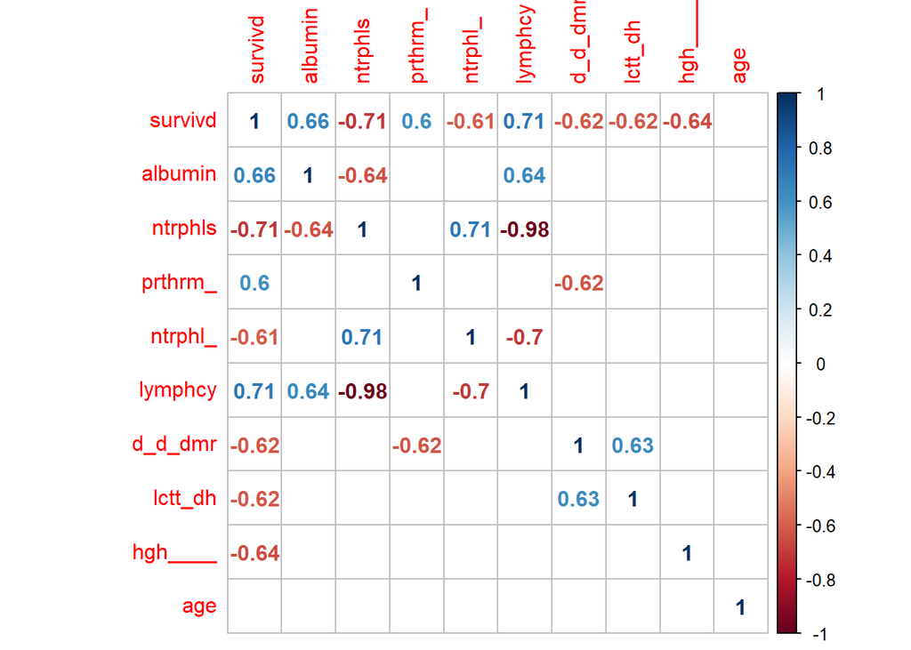

Age doesn’t have any significant correlation with any of the biomarkers.

### Final biomarkers

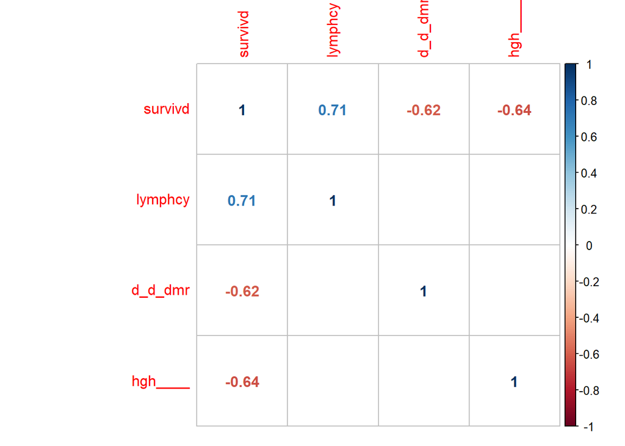

### Survival vs biomarkers

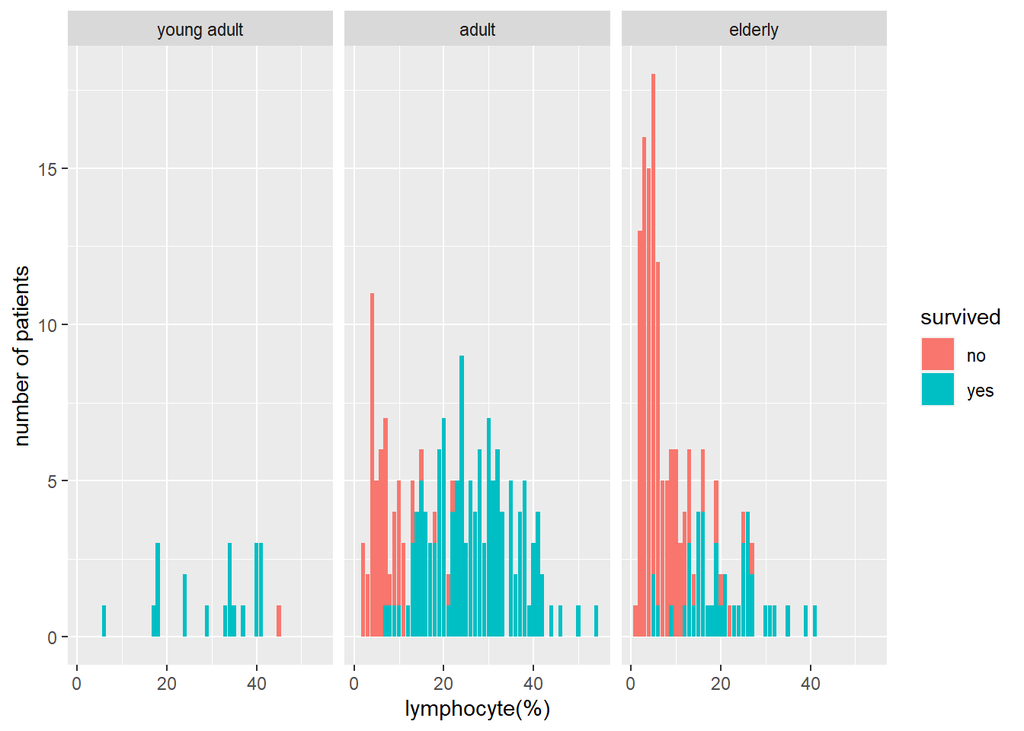

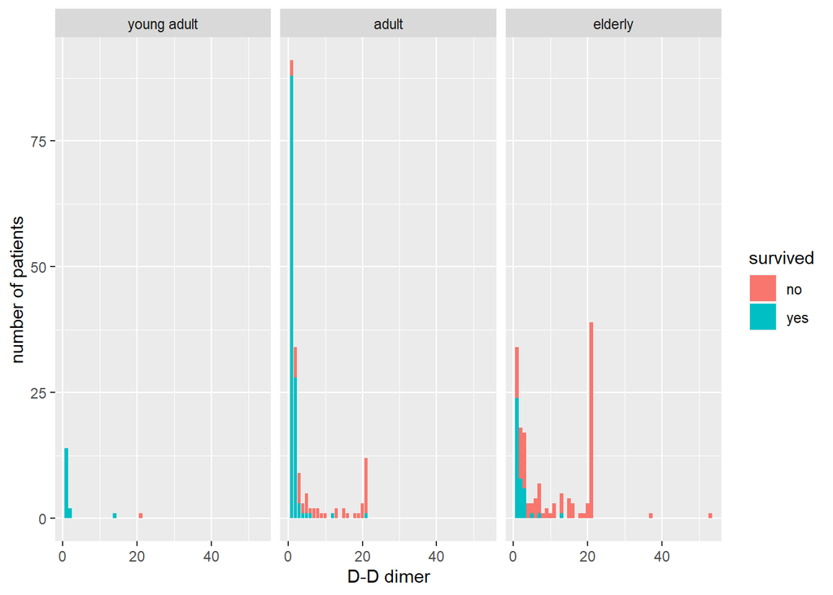

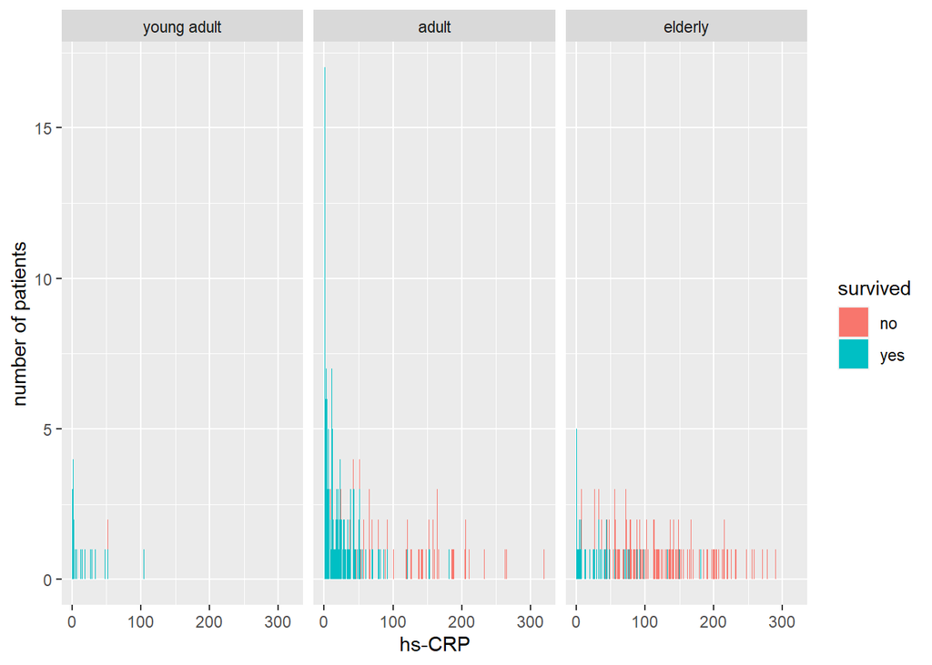

## Classificator

Each patient is described with chosen earlier biomarkers (mean of all of his results), age and label if he survived.

If the value of a biomark is NA then it is filled with median value from dataset.

### Summary of data for classificator

|  | age | survived | lymphocyte | d_d_dimer | hs_crp |
| --- | --- | --- | --- | --- | --- |
|  | Min. :18.00 | no :174 | Min. : 0.1125 | Min. : 0.2100 | Min. : 0.10 |
|  | 1st Qu.:46.00 | yes:201 | 1st Qu.: 5.3857 | 1st Qu.: 0.5571 | 1st Qu.: 13.17 |
|  | Median :62.00 | NA | Median :14.6571 | Median : 1.3500 | Median : 48.70 |
|  | Mean :58.83 | NA | Mean :16.6437 | Mean : 5.6627 | Mean : 71.39 |
|  | 3rd Qu.:70.00 | NA | 3rd Qu.:25.4600 | 3rd Qu.: 6.9280 | 3rd Qu.:116.77 |
|  | Max. :95.00 | NA | Max. :53.4429 | Max. :52.9091 | Max. :320.00 |

### Results

For classification was used random forest. 70% of the dataset was used for training, remaining 30% for testing.

```
## Random Forest
##
## 263 samples
##   4 predictor
##   2 classes: 'no', 'yes'
##
## No pre-processing
## Resampling: Cross-Validated (10 fold, repeated 5 times)
## Summary of sample sizes: 236, 237, 237, 237, 237, 236, ...
## Resampling results across tuning parameters:
##
##   mtry  Accuracy   Kappa
##   2     0.9043875  0.8078671
##   3     0.9000855  0.7996150
##   4     0.8970940  0.7935757
##
## Accuracy was used to select the optimal model using the largest value.
## The final value used for the model was mtry = 2.
```

```
## Confusion Matrix and Statistics
##
##           Reference
## Prediction no yes
##        no  48   4
##        yes  4  56
##
##                Accuracy : 0.9286
##                  95% CI : (0.8641, 0.9687)
##     No Information Rate : 0.5357
##     P-Value [Acc > NIR] : <2e-16
##
##                   Kappa : 0.8564
##
##  Mcnemar's Test P-Value : 1
##
##             Sensitivity : 0.9231
##             Specificity : 0.9333
##          Pos Pred Value : 0.9231
##          Neg Pred Value : 0.9333
##              Prevalence : 0.4643
##          Detection Rate : 0.4286
##    Detection Prevalence : 0.4643
##       Balanced Accuracy : 0.9282
##
##        'Positive' Class : no
##
```

### Analysis of the classificator results

The best result for the classificator would be to tell who is not going to survive, so the medics could try to save them.

#### Sensitivity

Sensitivity measures the proportion of true positives that are correctly identified. Because the survival positive is set to “no”, this measure shows how many patients who would die were correctly identified. The result of 92% is not bad, but it should be better.

#### Specificity

Specificity measures the proportion of those who truly won’t die and are correctly identified as such. This result is a little less important, but during pandemic when hospitals are full, it’s good to be able to correctly diagnose that somebody will live and don’t need to stay in hospital.

#### Variable importance

```
## rf variable importance
##
##            Overall
## lymphocyte   67.47
## hs_crp       30.62
## d_d_dimer    17.61
## age          12.73
```

Lymphocytes are the most important factor in the classification.

Surprisingly, age plays the least important role.